# Number of cigarettes

# 1 Description of DataSchema variable

The description of harmonised variable is the following:

- Short name: `n_cigarettes`
- Variable label: `Number of cigarettes smoked per week`
- Variable description: `Number of cigarettes smoked per week. Current smokers cigarettes only`
- Domain: `Lifestyle and health behaviours`
- Value type: `continuous`
- Category missings:

| **Code** | **Category Label** |
| --- | --- |
| 991 | CAPI/interviewer error |
| 992 | Impute |
| 993 | Disable to measure |
| 994 | Not attempt/not done |
| 995 | Does not answer |
| 996 | Not applicable |
| 997 | Refuse |
| 998 | Do not know |
| 999 | Missing |

# 2 Data process

## 2.1 Cuba

### 2.1.1 Wave 1

#### 2.1.1.1 Study-specific variable description

| **Name** | `PCIGDOSE` |
| --- | --- |
| **Label** | `amount smoked` |
| **Table name** | `1066-Cuba-Baseline` |
| **Categories** | `continuous` |
| **Missings** | `NA` |
| **Description** |  |

PCIGDOSE

| Sample size | Missing values |
| --- | --- |
| 2813 | 1554 |

Summary

| Min. | 1st Qu. | Median | Mean | 3rd Qu. | Max. | NA’s |
| --- | --- | --- | --- | --- | --- | --- |
| 1 | 4 | 10 | 15.52 | 20 | 60 | 1554 |

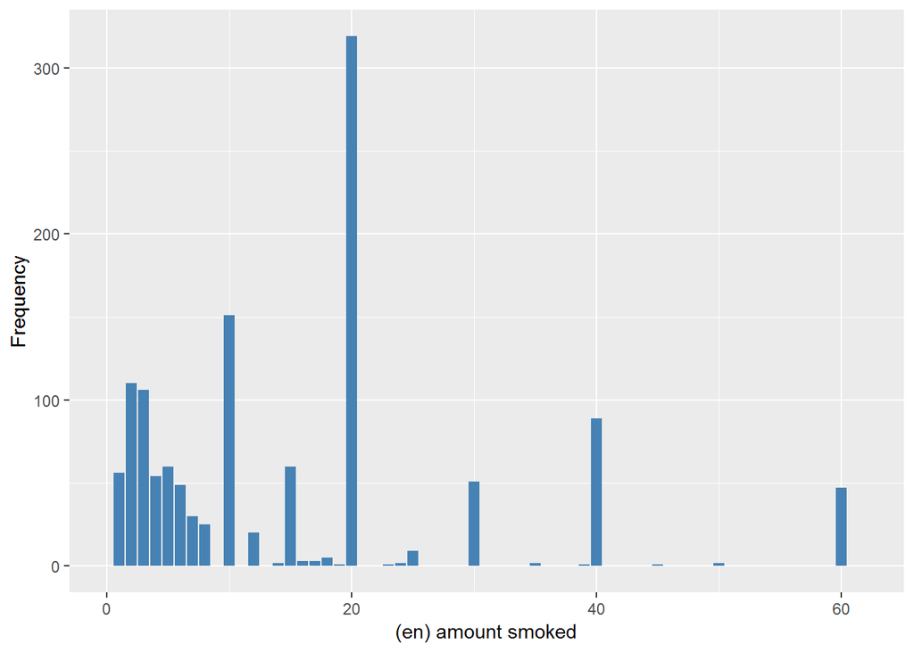

#### 2.1.1.2 Harmonisation algorithm

To compute the harmonize variable from the study-specific variable it has to be recoded as follows:

- `PCIGDOSE*7`
- `NA into 999`

```r
t1066_ds_cuba_w1 <- tibble(id = t1066_cuba_w1$id)
t1066_ds_cuba_w1$n_cigarettes <- Recode(t1066_cuba_w1$PCIGDOSE * 7, "NA = '999' ")
```

#### 2.1.1.3 Statistical description of the new harmonised variable

Number of cigarettes smoked per week

| Sample size | Missing values |
| --- | --- |
| 2813 | 1554 |

Values

|  | No-missings | 991 | 992 | 993 | 994 | 995 | 996 | 997 | 998 | 999 | NA |
| --- | --- | --- | --- | --- | --- | --- | --- | --- | --- | --- | --- |
| Frequency | 1259.00 | 0 | 0 | 0 | 0 | 0 | 0 | 0 | 0 | 1554.00 | 0 |
| Percentage | 44.76 | 0 | 0 | 0 | 0 | 0 | 0 | 0 | 0 | 55.24 | 0 |

Summary

| Min. | 1st Qu. | Median | Mean | 3rd Qu. | Max. |
| --- | --- | --- | --- | --- | --- |
| 7 | 28 | 70 | 108.6 | 140 | 420 |

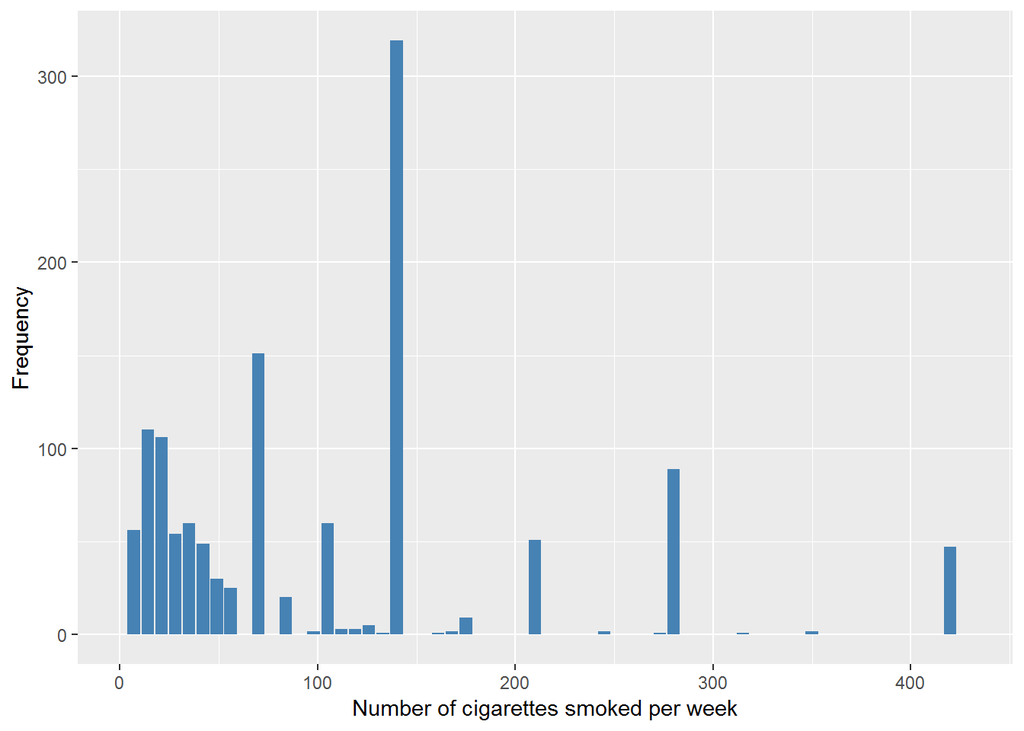

#### 2.1.1.4 Validation

|  | 1->7 | 2->14 | 3->21 | 4->28 | 5->35 | 6->42 | 7->49 | 8->56 | 10->70 | 12->84 | 14->98 | 15->105 | 16->112 | 17->119 | 18->126 | 19->133 | 20->140 | 23->161 | 24->168 | 25->175 | 30->210 | 35->245 | 39->273 | 40->280 | 45->315 | 50->350 | 60->420 | NA->999 |
| --- | --- | --- | --- | --- | --- | --- | --- | --- | --- | --- | --- | --- | --- | --- | --- | --- | --- | --- | --- | --- | --- | --- | --- | --- | --- | --- | --- | --- |
| BeforeH | 56 | 110 | 106 | 54 | 60 | 49 | 30 | 25 | 151 | 20 | 2 | 60 | 3 | 3 | 5 | 1 | 319 | 1 | 2 | 9 | 51 | 2 | 1 | 89 | 1 | 2 | 47 | 1554 |
| AfterH | 56 | 110 | 106 | 54 | 60 | 49 | 30 | 25 | 151 | 20 | 2 | 60 | 3 | 3 | 5 | 1 | 319 | 1 | 2 | 9 | 51 | 2 | 1 | 89 | 1 | 2 | 47 | 1554 |

### 2.1.2 Wave 2

#### 2.1.2.1 Study-specific variable description

| **Name** | `f_PCIGDOSE` |
| --- | --- |
| **Label** | `amount smoked` |
| **Table name** | `1066-Cuba-Followup` |
| **Categories** | `continuous` |
| **Missings** | `NA` |
| **Description** |  |

f_PCIGDOSE

| Sample size | Missing values |
| --- | --- |
| 2007 | 1768 |

Summary

| Min. | 1st Qu. | Median | Mean | 3rd Qu. | Max. | NA’s |
| --- | --- | --- | --- | --- | --- | --- |
| 1 | 3 | 10 | 10.76 | 20 | 40 | 1768 |

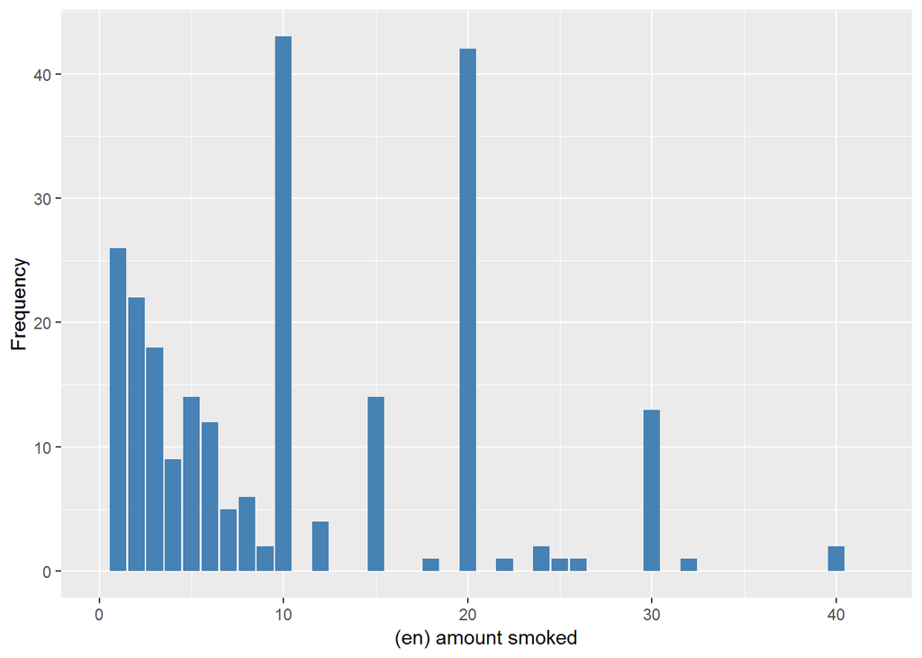

#### 2.1.2.2 Harmonisation algorithm

To compute the harmonize variable from the study-specific variable it has to be recoded as follows:

- `f_PCIGDOSE*7`
- `NA into 999`

```r
t1066_ds_cuba_w2 <- tibble(id = t1066_cuba_w2$id)
t1066_ds_cuba_w2$n_cigarettes <- Recode(t1066_cuba_w2$f_PCIGDOSE * 7, "NA = '999' ")
t1066_ds_cuba_w2$n_cigarettes <- labelled(t1066_ds_cuba_w2$n_cigarettes, labels = c(Missing = 999,
    Do_not_know = 998, Refuse = 997, Not_applicable = 996, Does_not_answer = 995,
    Not_attempt_not_done = 994, Disable_to_measure = 993, Impute = 992, CAPI_interviewer_error = 991))
```

#### 2.1.2.3 Statistical description of the new harmonised variable

Number of cigarettes smoked per week

| Sample size | Missing values |
| --- | --- |
| 2007 | 1768 |

Values

|  | No-missings | 991 | 992 | 993 | 994 | 995 | 996 | 997 | 998 | 999 | NA |
| --- | --- | --- | --- | --- | --- | --- | --- | --- | --- | --- | --- |
| Frequency | 239.00 | 0 | 0 | 0 | 0 | 0 | 0 | 0 | 0 | 1768.00 | 0 |
| Percentage | 11.91 | 0 | 0 | 0 | 0 | 0 | 0 | 0 | 0 | 88.09 | 0 |

Summary

| Min. | 1st Qu. | Median | Mean | 3rd Qu. | Max. |
| --- | --- | --- | --- | --- | --- |
| 7 | 21 | 70 | 75.33 | 140 | 280 |

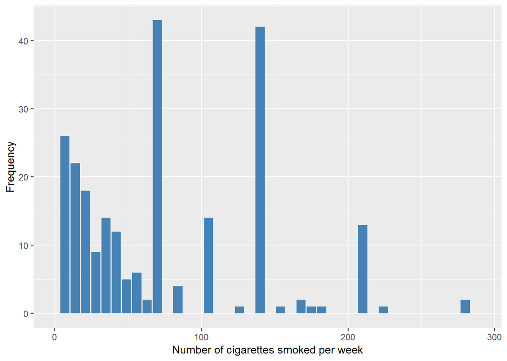

#### 2.1.2.4 Validation

|  | 1->7 | 2->14 | 3->21 | 4->28 | 5->35 | 6->42 | 7->49 | 8->56 | 9->63 | 10->70 | 12->84 | 15->105 | 18->126 | 20->140 | 22->154 | 24->168 | 25->175 | 26->182 | 30->210 | 32->224 | 40->280 | NA->999 |
| --- | --- | --- | --- | --- | --- | --- | --- | --- | --- | --- | --- | --- | --- | --- | --- | --- | --- | --- | --- | --- | --- | --- |
| BeforeH | 26 | 22 | 18 | 9 | 14 | 12 | 5 | 6 | 2 | 43 | 4 | 14 | 1 | 42 | 1 | 2 | 1 | 1 | 13 | 1 | 2 | 1768 |
| AfterH | 26 | 22 | 18 | 9 | 14 | 12 | 5 | 6 | 2 | 43 | 4 | 14 | 1 | 42 | 1 | 2 | 1 | 1 | 13 | 1 | 2 | 1768 |

## 2.2 India

### 2.2.1 Wave 1

#### 2.2.1.1 Study-specific variable description

| **Name** | `PCIGDOSE` |
| --- | --- |
| **Label** | `amount smoked` |
| **Table name** | `1066-India-Baseline` |
| **Categories** | `continuous` |
| **Missings** | `NA` |
| **Description** |  |

PCIGDOSE

| Sample size | Missing values |
| --- | --- |
| 2004 | 1223 |

Summary

| Min. | 1st Qu. | Median | Mean | 3rd Qu. | Max. | NA’s |
| --- | --- | --- | --- | --- | --- | --- |
| 1 | 1 | 3 | 6.298 | 10 | 60 | 1223 |

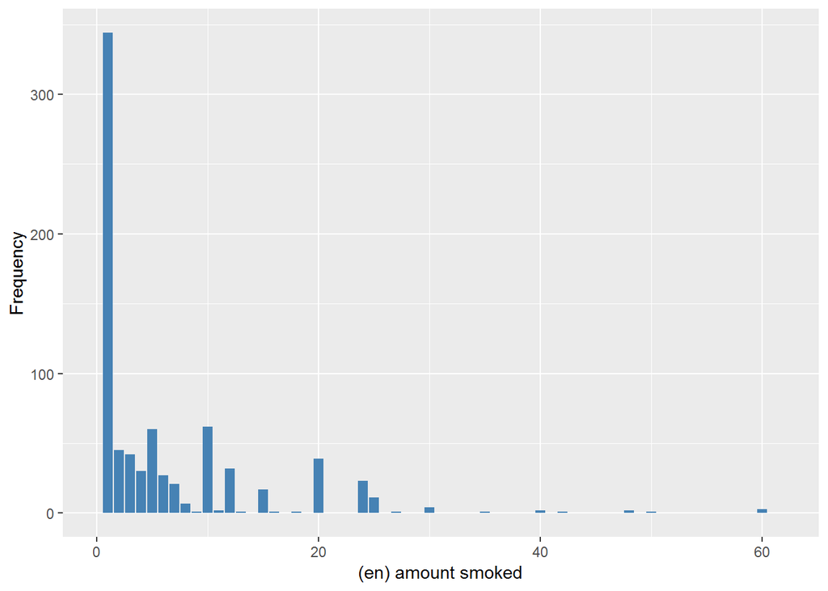

#### 2.2.1.2 Harmonisation algorithm

To compute the harmonize variable from the study-specific variable it has to be recoded as follows:

- `PCIGDOSE*7`
- `NA into 999`

```r
t1066_ds_india_w1 <- tibble(id = t1066_india_w1$id)
t1066_ds_india_w1$n_cigarettes <- Recode(t1066_india_w1$PCIGDOSE * 7, "NA = '999' ")
t1066_ds_india_w1$n_cigarettes <- labelled(t1066_ds_india_w1$n_cigarettes, labels = c(Missing = 999,
    Do_not_know = 998, Refuse = 997, Not_applicable = 996, Does_not_answer = 995,
    Not_attempt_not_done = 994, Disable_to_measure = 993, Impute = 992, CAPI_interviewer_error = 991))
```

#### 2.2.1.3 Statistical description of the new harmonised variable

Number of cigarettes smoked per week

| Sample size | Missing values |
| --- | --- |
| 2004 | 1223 |

Values

|  | No-missings | 991 | 992 | 993 | 994 | 995 | 996 | 997 | 998 | 999 | NA |
| --- | --- | --- | --- | --- | --- | --- | --- | --- | --- | --- | --- |
| Frequency | 781.00 | 0 | 0 | 0 | 0 | 0 | 0 | 0 | 0 | 1223.00 | 0 |
| Percentage | 38.97 | 0 | 0 | 0 | 0 | 0 | 0 | 0 | 0 | 61.03 | 0 |

Summary

| Min. | 1st Qu. | Median | Mean | 3rd Qu. | Max. |
| --- | --- | --- | --- | --- | --- |
| 7 | 7 | 21 | 44.09 | 70 | 420 |

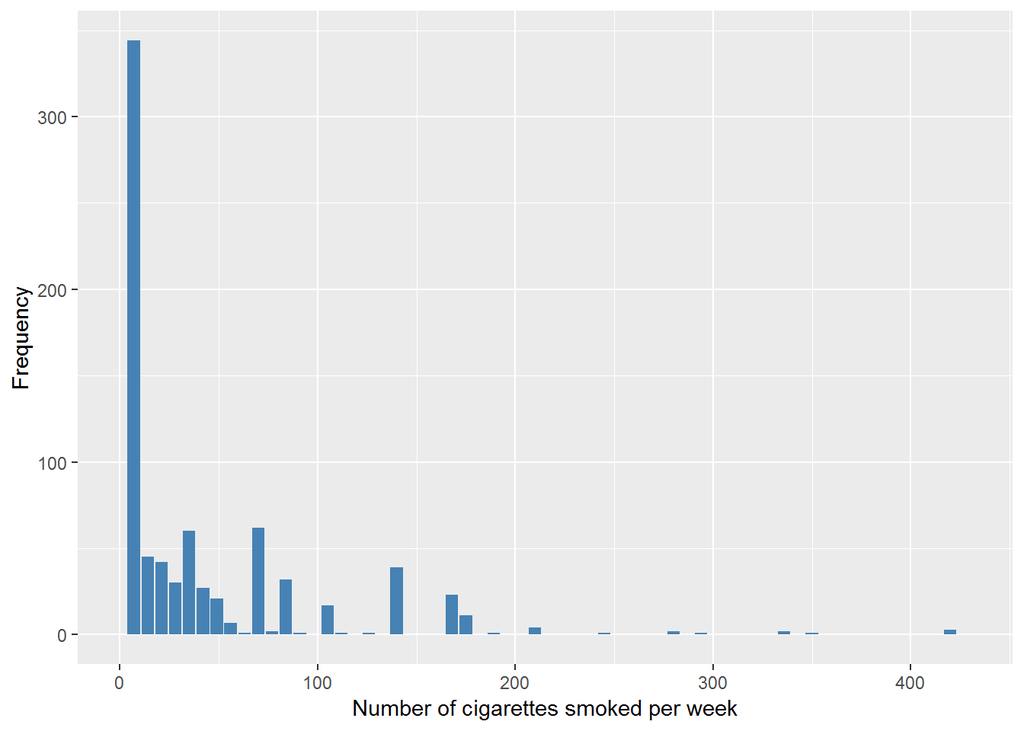

#### 2.2.1.4 Validation

|  | 1->7 | 2->14 | 3->21 | 4->28 | 5->35 | 6->42 | 7->49 | 8->56 | 9->63 | 10->70 | 11->77 | 12->84 | 13->91 | 15->105 | 16->112 | 18->126 | 20->140 | 24->168 | 25->175 | 27->189 | 30->210 | 35->245 | 40->280 | 42->294 | 48->336 | 50->350 | 60->420 | NA->999 |
| --- | --- | --- | --- | --- | --- | --- | --- | --- | --- | --- | --- | --- | --- | --- | --- | --- | --- | --- | --- | --- | --- | --- | --- | --- | --- | --- | --- | --- |
| BeforeH | 344 | 45 | 42 | 30 | 60 | 27 | 21 | 7 | 1 | 62 | 2 | 32 | 1 | 17 | 1 | 1 | 39 | 23 | 11 | 1 | 4 | 1 | 2 | 1 | 2 | 1 | 3 | 1223 |
| AfterH | 344 | 45 | 42 | 30 | 60 | 27 | 21 | 7 | 1 | 62 | 2 | 32 | 1 | 17 | 1 | 1 | 39 | 23 | 11 | 1 | 4 | 1 | 2 | 1 | 2 | 1 | 3 | 1223 |

## 2.3 Urban China

### 2.3.1 Wave 1

#### 2.3.1.1 Study-specific variable description

| **Name** | `PCIGDOSE` |
| --- | --- |
| **Label** | `amount smoked` |
| **Table name** | `1066-UrbanChina-Baseline` |
| **Categories** | `continuous` |
| **Missings** | `NA` |
| **Description** |  |

PCIGDOSE

| Sample size | Missing values |
| --- | --- |
| 1160 | 886 |

Summary

| Min. | 1st Qu. | Median | Mean | 3rd Qu. | Max. | NA’s |
| --- | --- | --- | --- | --- | --- | --- |
| 1 | 7 | 10 | 14.46 | 20 | 60 | 886 |

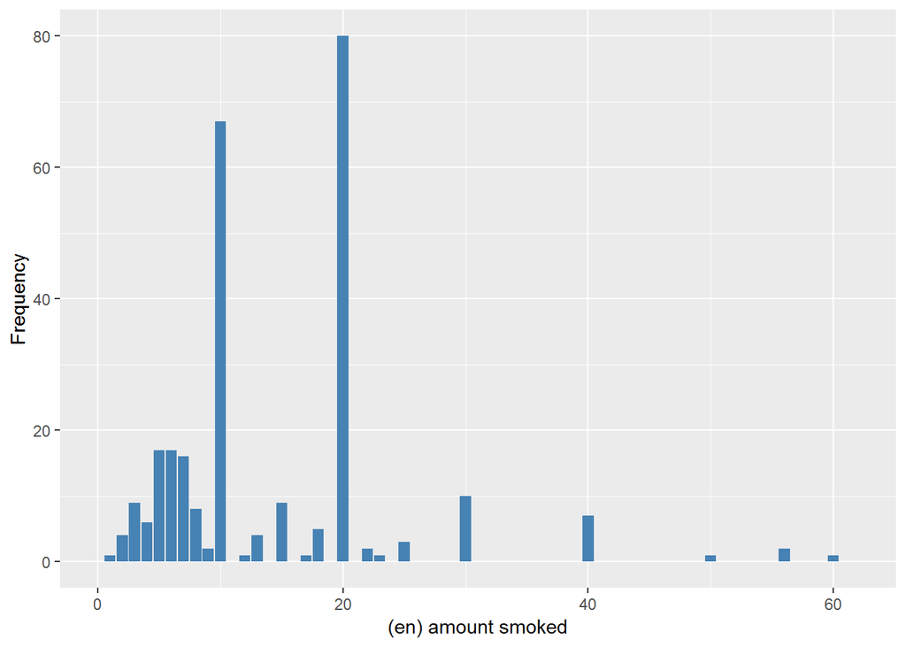

#### 2.3.1.2 Harmonisation algorithm

To compute the harmonize variable from the study-specific variable it has to be recoded as follows:

- `PCIGDOSE*7`
- `NA into 999`

```r
t1066_ds_UCh_w1 <- tibble(id = t1066_UCh_w1$id)
t1066_ds_UCh_w1$n_cigarettes <- Recode(t1066_UCh_w1$PCIGDOSE * 7, "NA = '999' ")
t1066_ds_UCh_w1$n_cigarettes <- labelled(t1066_ds_UCh_w1$n_cigarettes, labels = c(Missing = 999,
    Do_not_know = 998, Refuse = 997, Not_applicable = 996, Does_not_answer = 995,
    Not_attempt_not_done = 994, Disable_to_measure = 993, Impute = 992, CAPI_interviewer_error = 991))
```

#### 2.3.1.3 Statistical description of the new harmonised variable

Number of cigarettes smoked per week

| Sample size | Missing values |
| --- | --- |
| 1160 | 886 |

Values

|  | No-missings | 991 | 992 | 993 | 994 | 995 | 996 | 997 | 998 | 999 | NA |
| --- | --- | --- | --- | --- | --- | --- | --- | --- | --- | --- | --- |
| Frequency | 274.00 | 0 | 0 | 0 | 0 | 0 | 0 | 0 | 0 | 886.00 | 0 |
| Percentage | 23.62 | 0 | 0 | 0 | 0 | 0 | 0 | 0 | 0 | 76.38 | 0 |

Summary

| Min. | 1st Qu. | Median | Mean | 3rd Qu. | Max. |
| --- | --- | --- | --- | --- | --- |
| 7 | 49 | 70 | 101.2 | 140 | 420 |

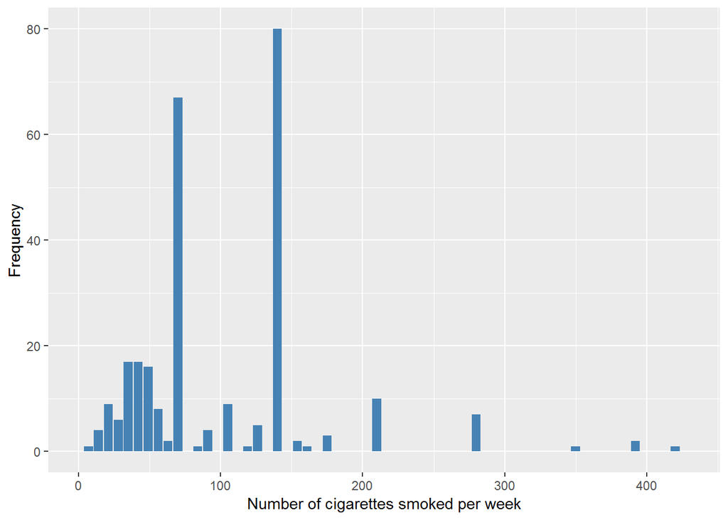

#### 2.3.1.4 Validation

|  | 1->7 | 2->14 | 3->21 | 4->28 | 5->35 | 6->42 | 7->49 | 8->56 | 9->63 | 10->70 | 12->84 | 13->91 | 15->105 | 17->119 | 18->126 | 20->140 | 22->154 | 23->161 | 25->175 | 30->210 | 40->280 | 50->350 | 56->392 | 60->420 | NA->999 |
| --- | --- | --- | --- | --- | --- | --- | --- | --- | --- | --- | --- | --- | --- | --- | --- | --- | --- | --- | --- | --- | --- | --- | --- | --- | --- |
| BeforeH | 1 | 4 | 9 | 6 | 17 | 17 | 16 | 8 | 2 | 67 | 1 | 4 | 9 | 1 | 5 | 80 | 2 | 1 | 3 | 10 | 7 | 1 | 2 | 1 | 886 |
| AfterH | 1 | 4 | 9 | 6 | 17 | 17 | 16 | 8 | 2 | 67 | 1 | 4 | 9 | 1 | 5 | 80 | 2 | 1 | 3 | 10 | 7 | 1 | 2 | 1 | 886 |

### 2.3.2 Wave 2

#### 2.3.2.1 Study-specific variable description

| **Name** | `f_PCIGDOSE` |
| --- | --- |
| **Label** | `amount smoked` |
| **Table name** | `1066-UrbanChina-Followup` |
| **Categories** | `continuous` |
| **Missings** | `NA` |
| **Description** |  |

f_PCIGDOSE

| Sample size | Missing values |
| --- | --- |
| 741 | 620 |

Summary

| Min. | 1st Qu. | Median | Mean | 3rd Qu. | Max. | NA’s |
| --- | --- | --- | --- | --- | --- | --- |
| 1 | 6 | 10 | 10.93 | 15 | 40 | 620 |

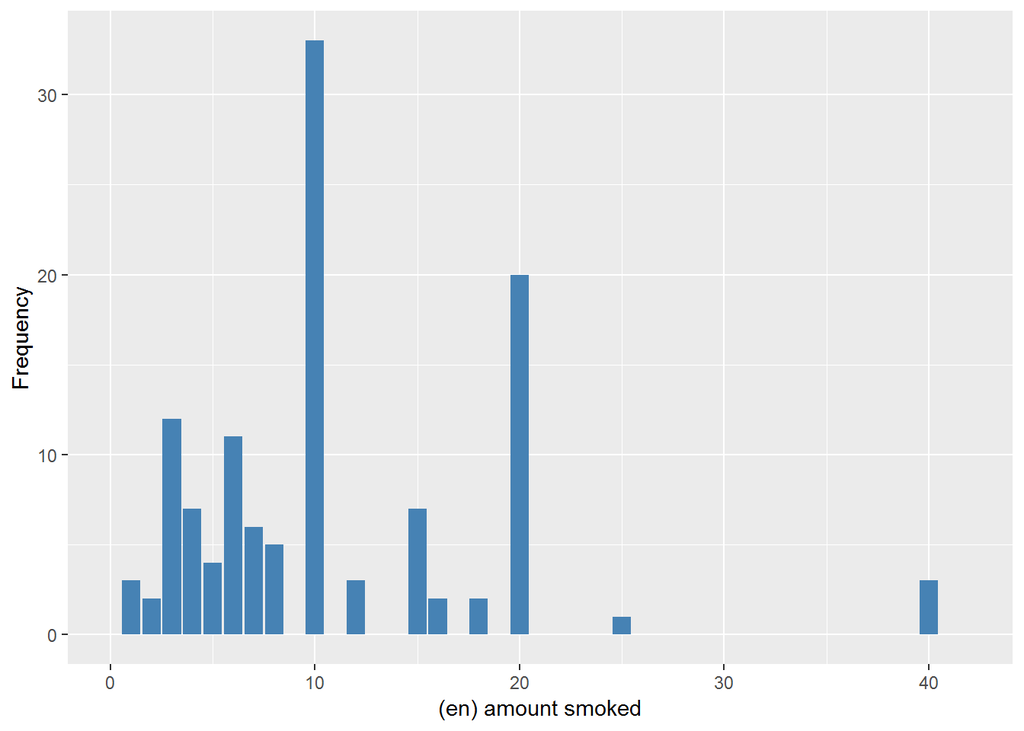

#### 2.3.2.2 Harmonisation algorithm

To compute the harmonize variable from the study-specific variable it has to be recoded as follows:

- `f_PCIGDOSE*7`
- `NA into 999`

```r
t1066_ds_UCh_w2 <- tibble(id = t1066_UCh_w2$id)
t1066_ds_UCh_w2$n_cigarettes <- Recode(t1066_UCh_w2$f_PCIGDOSE * 7, "NA = '999' ")
t1066_ds_UCh_w2$n_cigarettes <- labelled(t1066_ds_UCh_w2$n_cigarettes, labels = c(Missing = 999,
    Do_not_know = 998, Refuse = 997, Not_applicable = 996, Does_not_answer = 995,
    Not_attempt_not_done = 994, Disable_to_measure = 993, Impute = 992, CAPI_interviewer_error = 991))
```

#### 2.3.2.3 Statistical description of the new harmonised variable

Number of cigarettes smoked per week

| Sample size | Missing values |
| --- | --- |
| 741 | 620 |

Values

|  | No-missings | 991 | 992 | 993 | 994 | 995 | 996 | 997 | 998 | 999 | NA |
| --- | --- | --- | --- | --- | --- | --- | --- | --- | --- | --- | --- |
| Frequency | 121.00 | 0 | 0 | 0 | 0 | 0 | 0 | 0 | 0 | 620.00 | 0 |
| Percentage | 16.33 | 0 | 0 | 0 | 0 | 0 | 0 | 0 | 0 | 83.67 | 0 |

Summary

| Min. | 1st Qu. | Median | Mean | 3rd Qu. | Max. |
| --- | --- | --- | --- | --- | --- |
| 7 | 42 | 70 | 76.54 | 105 | 280 |

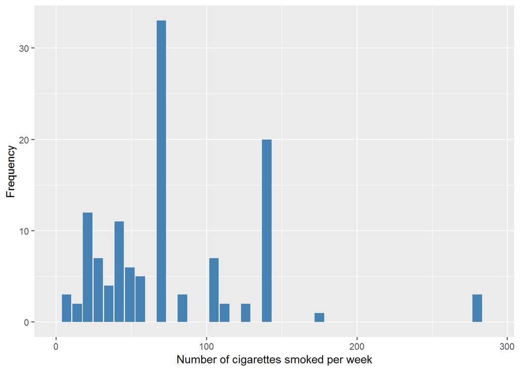

#### 2.3.2.4 Validation

|  | 1->7 | 2->14 | 3->21 | 4->28 | 5->35 | 6->42 | 7->49 | 8->56 | 10->70 | 12->84 | 15->105 | 16->112 | 18->126 | 20->140 | 25->175 | 40->280 | NA->999 |
| --- | --- | --- | --- | --- | --- | --- | --- | --- | --- | --- | --- | --- | --- | --- | --- | --- | --- |
| BeforeH | 3 | 2 | 12 | 7 | 4 | 11 | 6 | 5 | 33 | 3 | 7 | 2 | 2 | 20 | 1 | 3 | 620 |
| AfterH | 3 | 2 | 12 | 7 | 4 | 11 | 6 | 5 | 33 | 3 | 7 | 2 | 2 | 20 | 1 | 3 | 620 |

## 2.4 Rural China

### 2.4.1 Wave 1

#### 2.4.1.1 Study-specific variable description

| **Name** | `PCIGDOSE` |
| --- | --- |
| **Label** | `amount smoked` |
| **Table name** | `1066-RuralChina-Baseline` |
| **Categories** | `continuous` |
| **Missings** | `NA` |
| **Description** |  |

PCIGDOSE

| Sample size | Missing values |
| --- | --- |
| 1002 | 667 |

Summary

| Min. | 1st Qu. | Median | Mean | 3rd Qu. | Max. | NA’s |
| --- | --- | --- | --- | --- | --- | --- |
| 2 | 10 | 13 | 13.82 | 20 | 60 | 667 |

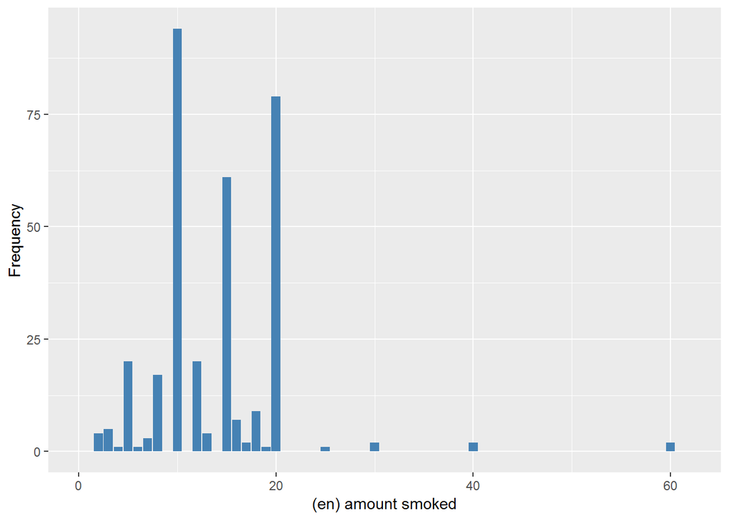

#### 2.4.1.2 Harmonisation algorithm

To compute the harmonize variable from the study-specific variable it has to be recoded as follows:

- `PCIGDOSE*7`
- `NA into 999`

```r
t1066_ds_RCh_w1 <- tibble(id = t1066_RCh_w1$id)
t1066_ds_RCh_w1$n_cigarettes <- Recode(t1066_RCh_w1$PCIGDOSE * 7, "NA = '999' ")
t1066_ds_RCh_w1$n_cigarettes <- labelled(t1066_ds_RCh_w1$n_cigarettes, labels = c(Missing = 999,
    Do_not_know = 998, Refuse = 997, Not_applicable = 996, Does_not_answer = 995,
    Not_attempt_not_done = 994, Disable_to_measure = 993, Impute = 992, CAPI_interviewer_error = 991))
```

#### 2.4.1.3 Statistical description of the new harmonised variable

Number of cigarettes smoked per week

| Sample size | Missing values |
| --- | --- |
| 1002 | 667 |

Values

|  | No-missings | 991 | 992 | 993 | 994 | 995 | 996 | 997 | 998 | 999 | NA |
| --- | --- | --- | --- | --- | --- | --- | --- | --- | --- | --- | --- |
| Frequency | 335.00 | 0 | 0 | 0 | 0 | 0 | 0 | 0 | 0 | 667.00 | 0 |
| Percentage | 33.43 | 0 | 0 | 0 | 0 | 0 | 0 | 0 | 0 | 66.57 | 0 |

Summary

| Min. | 1st Qu. | Median | Mean | 3rd Qu. | Max. |
| --- | --- | --- | --- | --- | --- |
| 14 | 70 | 91 | 96.73 | 140 | 420 |

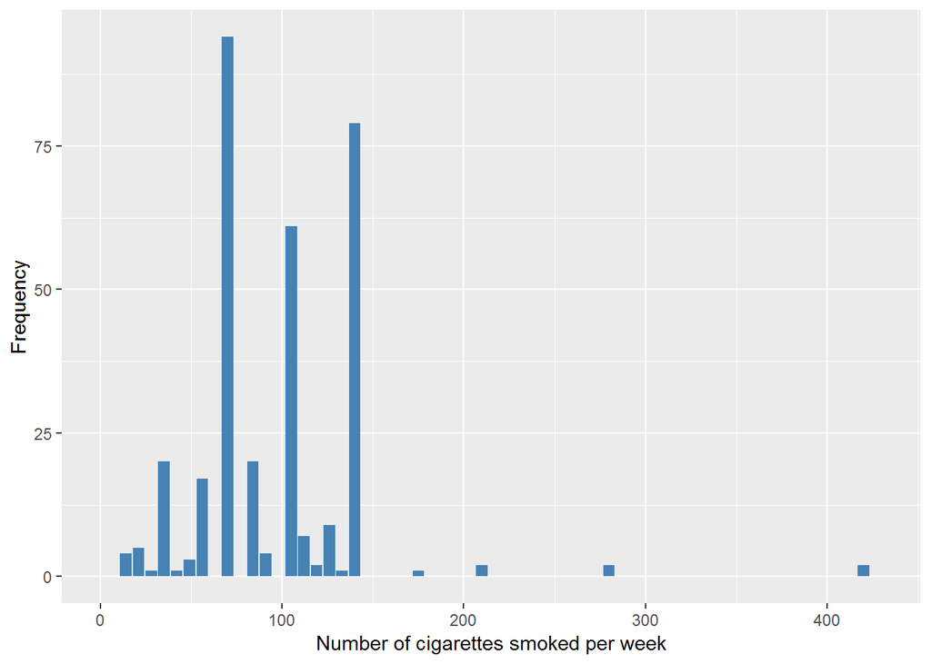

#### 2.4.1.4 Validation

|  | 2->14 | 3->21 | 4->28 | 5->35 | 6->42 | 7->49 | 8->56 | 10->70 | 12->84 | 13->91 | 15->105 | 16->112 | 17->119 | 18->126 | 19->133 | 20->140 | 25->175 | 30->210 | 40->280 | 60->420 | NA->999 |
| --- | --- | --- | --- | --- | --- | --- | --- | --- | --- | --- | --- | --- | --- | --- | --- | --- | --- | --- | --- | --- | --- |
| BeforeH | 4 | 5 | 1 | 20 | 1 | 3 | 17 | 94 | 20 | 4 | 61 | 7 | 2 | 9 | 1 | 79 | 1 | 2 | 2 | 2 | 667 |
| AfterH | 4 | 5 | 1 | 20 | 1 | 3 | 17 | 94 | 20 | 4 | 61 | 7 | 2 | 9 | 1 | 79 | 1 | 2 | 2 | 2 | 667 |

### 2.4.2 Wave 2

#### 2.4.2.1 Study-specific variable description

| **Name** | `f_PCIGDOSE` |
| --- | --- |
| **Label** | `amount smoked` |
| **Table name** | `1066-RuralChina-Followup` |
| **Categories** | `continuous` |
| **Missings** | `NA` |
| **Description** |  |

f_PCIGDOSE

| Sample size | Missing values |
| --- | --- |
| 711 | 504 |

Summary

| Min. | 1st Qu. | Median | Mean | 3rd Qu. | Max. | NA’s |
| --- | --- | --- | --- | --- | --- | --- |
| 1 | 6 | 10 | 11.36 | 15 | 60 | 504 |

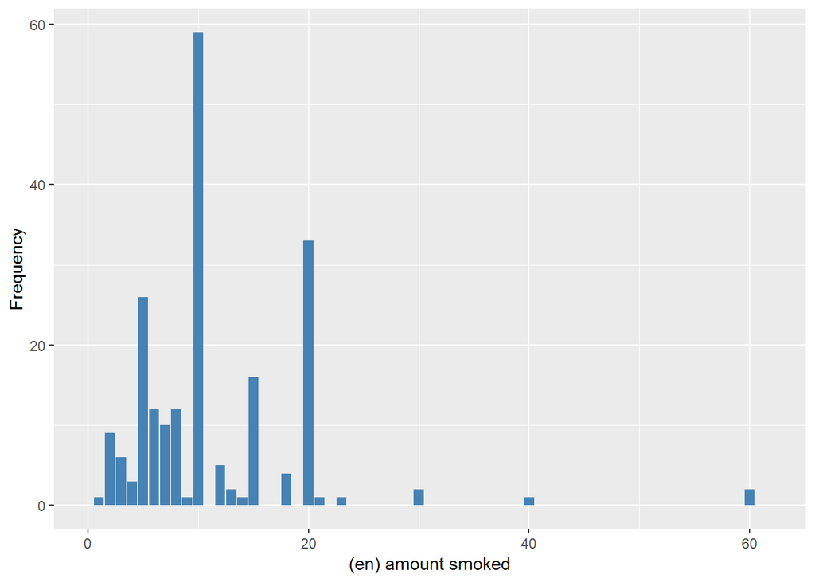

#### 2.4.2.2 Harmonisation algorithm

To compute the harmonize variable from the study-specific variable it has to be recoded as follows:

- `f_PCIGDOSE*7`
- `NA into 999`

```r
t1066_ds_RCh_w2 <- tibble(id = t1066_RCh_w2$id)
t1066_ds_RCh_w2$n_cigarettes <- Recode(t1066_RCh_w2$f_PCIGDOSE * 7, "NA = '999' ")
t1066_ds_RCh_w2$n_cigarettes <- labelled(t1066_ds_RCh_w2$n_cigarettes, labels = c(Missing = 999,
    Do_not_know = 998, Refuse = 997, Not_applicable = 996, Does_not_answer = 995,
    Not_attempt_not_done = 994, Disable_to_measure = 993, Impute = 992, CAPI_interviewer_error = 991))
```

#### 2.4.2.3 Statistical description of the new harmonised variable

Number of cigarettes smoked per week

| Sample size | Missing values |
| --- | --- |
| 711 | 504 |

Values

|  | No-missings | 991 | 992 | 993 | 994 | 995 | 996 | 997 | 998 | 999 | NA |
| --- | --- | --- | --- | --- | --- | --- | --- | --- | --- | --- | --- |
| Frequency | 207.00 | 0 | 0 | 0 | 0 | 0 | 0 | 0 | 0 | 504.00 | 0 |
| Percentage | 29.11 | 0 | 0 | 0 | 0 | 0 | 0 | 0 | 0 | 70.89 | 0 |

Summary

| Min. | 1st Qu. | Median | Mean | 3rd Qu. | Max. |
| --- | --- | --- | --- | --- | --- |
| 7 | 42 | 70 | 79.54 | 105 | 420 |

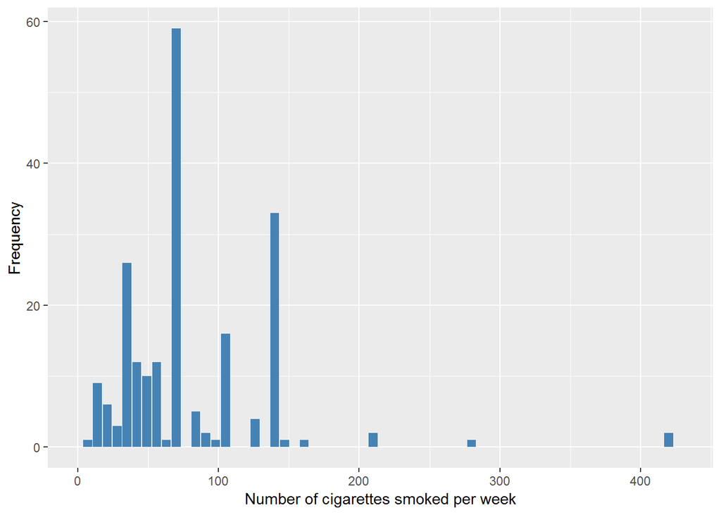

#### 2.4.2.4 Validation

|  | 1->7 | 2->14 | 3->21 | 4->28 | 5->35 | 6->42 | 7->49 | 8->56 | 9->63 | 10->70 | 12->84 | 13->91 | 14->98 | 15->105 | 18->126 | 20->140 | 21->147 | 23->161 | 30->210 | 40->280 | 60->420 | NA->999 |
| --- | --- | --- | --- | --- | --- | --- | --- | --- | --- | --- | --- | --- | --- | --- | --- | --- | --- | --- | --- | --- | --- | --- |
| BeforeH | 1 | 9 | 6 | 3 | 26 | 12 | 10 | 12 | 1 | 59 | 5 | 2 | 1 | 16 | 4 | 33 | 1 | 1 | 2 | 1 | 2 | 504 |
| AfterH | 1 | 9 | 6 | 3 | 26 | 12 | 10 | 12 | 1 | 59 | 5 | 2 | 1 | 16 | 4 | 33 | 1 | 1 | 2 | 1 | 2 | 504 |

## 2.5 Dominican Republic

### 2.5.1 Wave 1

#### 2.5.1.1 Study-specific variable description

| **Name** | `PCIGDOSE` |
| --- | --- |
| **Label** | `amount smoked` |
| **Table name** | `1066-DominicanRepublic-Baseline` |
| **Categories** | `continuous` |
| **Missings** | `NA` |
| **Description** |  |

PCIGDOSE

| Sample size | Missing values |
| --- | --- |
| 2011 | 1074 |

Summary

| Min. | 1st Qu. | Median | Mean | 3rd Qu. | Max. | NA’s |
| --- | --- | --- | --- | --- | --- | --- |
| 1 | 3 | 6 | 11.93 | 20 | 60 | 1074 |

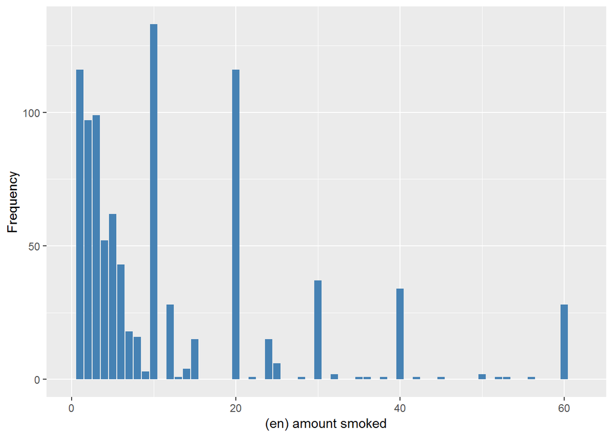

#### 2.5.1.2 Harmonisation algorithm

To compute the harmonize variable from the study-specific variable it has to be recoded as follows:

- `PCIGDOSE*7`
- `NA into 999`

```r
t1066_ds_DR_w1 <- tibble(id = t1066_DR_w1$id)
t1066_ds_DR_w1$n_cigarettes <- Recode(t1066_DR_w1$PCIGDOSE * 7, "NA = '999' ")
t1066_ds_DR_w1$n_cigarettes <- labelled(t1066_ds_DR_w1$n_cigarettes, labels = c(Missing = 999,
    Do_not_know = 998, Refuse = 997, Not_applicable = 996, Does_not_answer = 995,
    Not_attempt_not_done = 994, Disable_to_measure = 993, Impute = 992, CAPI_interviewer_error = 991))
```

#### 2.5.1.3 Statistical description of the new harmonised variable

Number of cigarettes smoked per week

| Sample size | Missing values |
| --- | --- |
| 2011 | 1074 |

Values

|  | No-missings | 991 | 992 | 993 | 994 | 995 | 996 | 997 | 998 | 999 | NA |
| --- | --- | --- | --- | --- | --- | --- | --- | --- | --- | --- | --- |
| Frequency | 937.00 | 0 | 0 | 0 | 0 | 0 | 0 | 0 | 0 | 1074.00 | 0 |
| Percentage | 46.59 | 0 | 0 | 0 | 0 | 0 | 0 | 0 | 0 | 53.41 | 0 |

Summary

| Min. | 1st Qu. | Median | Mean | 3rd Qu. | Max. |
| --- | --- | --- | --- | --- | --- |
| 7 | 21 | 42 | 83.48 | 140 | 420 |

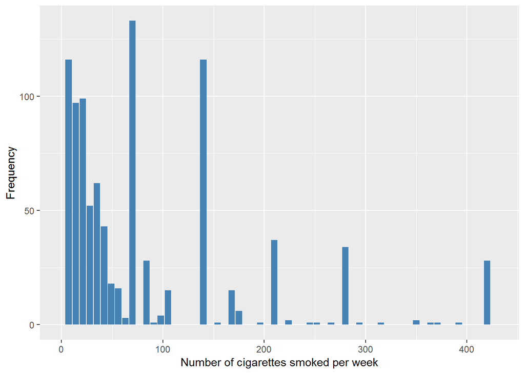

#### 2.5.1.4 Validation

|  | 1->7 | 2->14 | 3->21 | 4->28 | 5->35 | 6->42 | 7->49 | 8->56 | 9->63 | 10->70 | 12->84 | 13->91 | 14->98 | 15->105 | 20->140 | 22->154 | 24->168 | 25->175 | 28->196 | 30->210 | 32->224 | 35->245 | 36->252 | 38->266 | 40->280 | 42->294 | 45->315 | 50->350 | 52->364 | … |
| --- | --- | --- | --- | --- | --- | --- | --- | --- | --- | --- | --- | --- | --- | --- | --- | --- | --- | --- | --- | --- | --- | --- | --- | --- | --- | --- | --- | --- | --- | --- |
| BeforeH | 116 | 97 | 99 | 52 | 62 | 43 | 18 | 16 | 3 | 133 | 28 | 1 | 4 | 15 | 116 | 1 | 15 | 6 | 1 | 37 | 2 | 1 | 1 | 1 | 34 | 1 | 1 | 2 | 1 | … |
| AfterH | 116 | 97 | 99 | 52 | 62 | 43 | 18 | 16 | 3 | 133 | 28 | 1 | 4 | 15 | 116 | 1 | 15 | 6 | 1 | 37 | 2 | 1 | 1 | 1 | 34 | 1 | 1 | 2 | 1 | … |

### 2.5.2 Wave 2

#### 2.5.2.1 Study-specific variable description

| **Name** | `f_PCIGDOSE` |
| --- | --- |
| **Label** | `amount smoked` |
| **Table name** | `1066-DominicanRepublic-Followup` |
| **Categories** | `continuous` |
| **Missings** | `NA` |
| **Description** |  |

f_PCIGDOSE

| Sample size | Missing values |
| --- | --- |
| 1197 | 1086 |

Summary

| Min. | 1st Qu. | Median | Mean | 3rd Qu. | Max. | NA’s |
| --- | --- | --- | --- | --- | --- | --- |
| 1 | 2 | 4 | 7.045 | 10 | 60 | 1086 |

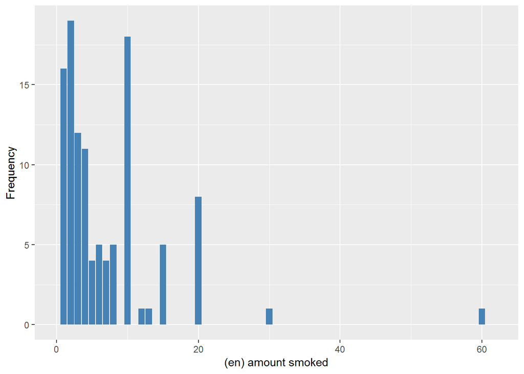

#### 2.5.2.2 Harmonisation algorithm

To compute the harmonize variable from the study-specific variable it has to be recoded as follows:

- `f_PCIGDOSE*7`
- `NA into 999`

```r
t1066_ds_DR_w2 <- tibble(id = t1066_DR_w2$id)
t1066_ds_DR_w2$n_cigarettes <- Recode(t1066_DR_w2$f_PCIGDOSE * 7, "NA = '999' ")
t1066_ds_DR_w2$n_cigarettes <- labelled(t1066_ds_DR_w2$n_cigarettes, labels = c(Missing = 999,
    Do_not_know = 998, Refuse = 997, Not_applicable = 996, Does_not_answer = 995,
    Not_attempt_not_done = 994, Disable_to_measure = 993, Impute = 992, CAPI_interviewer_error = 991))
```

#### 2.5.2.3 Statistical description of the new harmonised variable

Number of cigarettes smoked per week

| Sample size | Missing values |
| --- | --- |
| 1197 | 1086 |

Values

|  | No-missings | 991 | 992 | 993 | 994 | 995 | 996 | 997 | 998 | 999 | NA |
| --- | --- | --- | --- | --- | --- | --- | --- | --- | --- | --- | --- |
| Frequency | 111.00 | 0 | 0 | 0 | 0 | 0 | 0 | 0 | 0 | 1086.00 | 0 |
| Percentage | 9.27 | 0 | 0 | 0 | 0 | 0 | 0 | 0 | 0 | 90.73 | 0 |

Summary

| Min. | 1st Qu. | Median | Mean | 3rd Qu. | Max. |
| --- | --- | --- | --- | --- | --- |
| 7 | 14 | 28 | 49.32 | 70 | 420 |

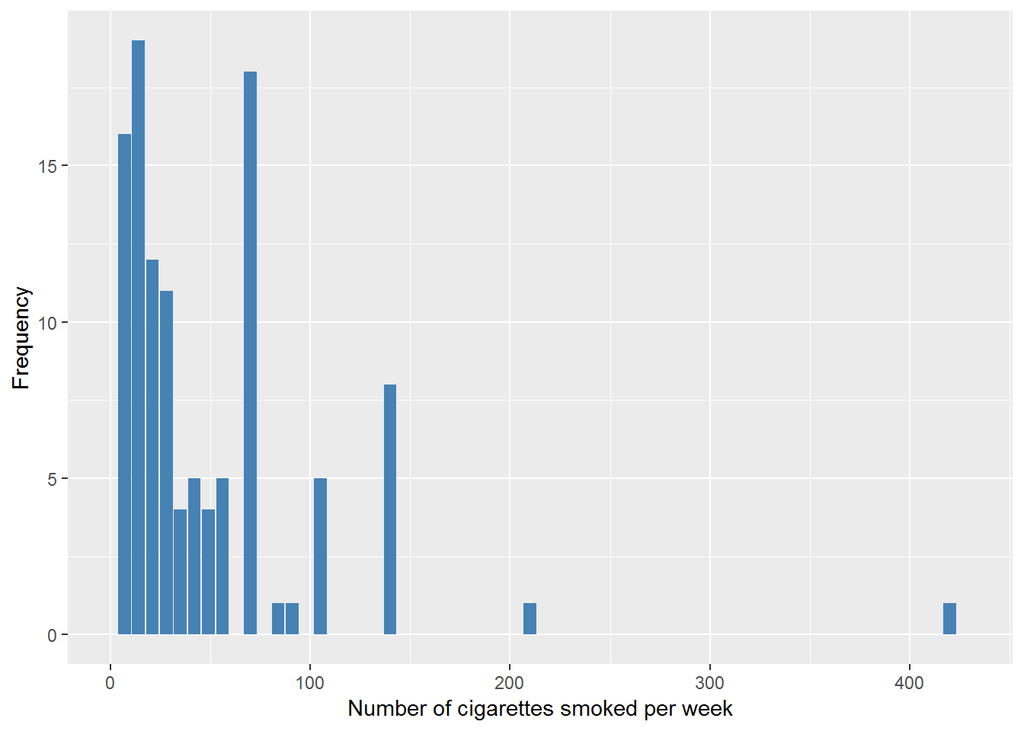

#### 2.5.2.4 Validation

|  | 1->7 | 2->14 | 3->21 | 4->28 | 5->35 | 6->42 | 7->49 | 8->56 | 10->70 | 12->84 | 13->91 | 15->105 | 20->140 | 30->210 | 60->420 | NA->999 |
| --- | --- | --- | --- | --- | --- | --- | --- | --- | --- | --- | --- | --- | --- | --- | --- | --- |
| BeforeH | 16 | 19 | 12 | 11 | 4 | 5 | 4 | 5 | 18 | 1 | 1 | 5 | 8 | 1 | 1 | 1086 |
| AfterH | 16 | 19 | 12 | 11 | 4 | 5 | 4 | 5 | 18 | 1 | 1 | 5 | 8 | 1 | 1 | 1086 |

## 2.6 Venezuela

### 2.6.1 Wave 1

#### 2.6.1.1 Study-specific variable description

| **Name** | `PCIGDOSE` |
| --- | --- |
| **Label** | `amount smoked` |
| **Table name** | `1066-Venezuela-Baseline` |
| **Categories** | `continuous` |
| **Missings** | `NA` |
| **Description** |  |

PCIGDOSE

| Sample size | Missing values |
| --- | --- |
| 1965 | 1173 |

Summary

| Min. | 1st Qu. | Median | Mean | 3rd Qu. | Max. | NA’s |
| --- | --- | --- | --- | --- | --- | --- |
| 1 | 2 | 4 | 9.553 | 10 | 60 | 1173 |

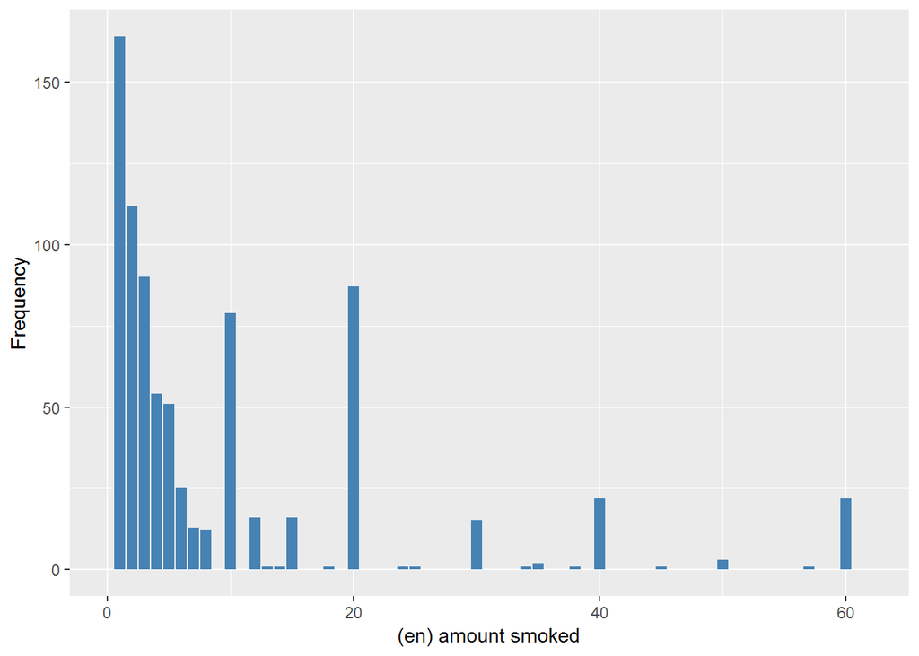

#### 2.6.1.2 Harmonisation algorithm

To compute the harmonize variable from the study-specific variable it has to be recoded as follows:

- `PCIGDOSE*7`
- `NA into 999`

```r
t1066_ds_Ven_w1 <- tibble(id = t1066_Ven_w1$id)
t1066_ds_Ven_w1$n_cigarettes <- Recode(t1066_Ven_w1$PCIGDOSE * 7, "NA = '999' ")
t1066_ds_Ven_w1$n_cigarettes <- labelled(t1066_ds_Ven_w1$n_cigarettes, labels = c(Missing = 999,
    Do_not_know = 998, Refuse = 997, Not_applicable = 996, Does_not_answer = 995,
    Not_attempt_not_done = 994, Disable_to_measure = 993, Impute = 992, CAPI_interviewer_error = 991))
```

#### 2.6.1.3 Statistical description of the new harmonised variable

Number of cigarettes smoked per week

| Sample size | Missing values |
| --- | --- |
| 1965 | 1173 |

Values

|  | No-missings | 991 | 992 | 993 | 994 | 995 | 996 | 997 | 998 | 999 | NA |
| --- | --- | --- | --- | --- | --- | --- | --- | --- | --- | --- | --- |
| Frequency | 792.00 | 0 | 0 | 0 | 0 | 0 | 0 | 0 | 0 | 1173.00 | 0 |
| Percentage | 40.31 | 0 | 0 | 0 | 0 | 0 | 0 | 0 | 0 | 59.69 | 0 |

Summary

| Min. | 1st Qu. | Median | Mean | 3rd Qu. | Max. |
| --- | --- | --- | --- | --- | --- |
| 7 | 14 | 28 | 66.87 | 70 | 420 |

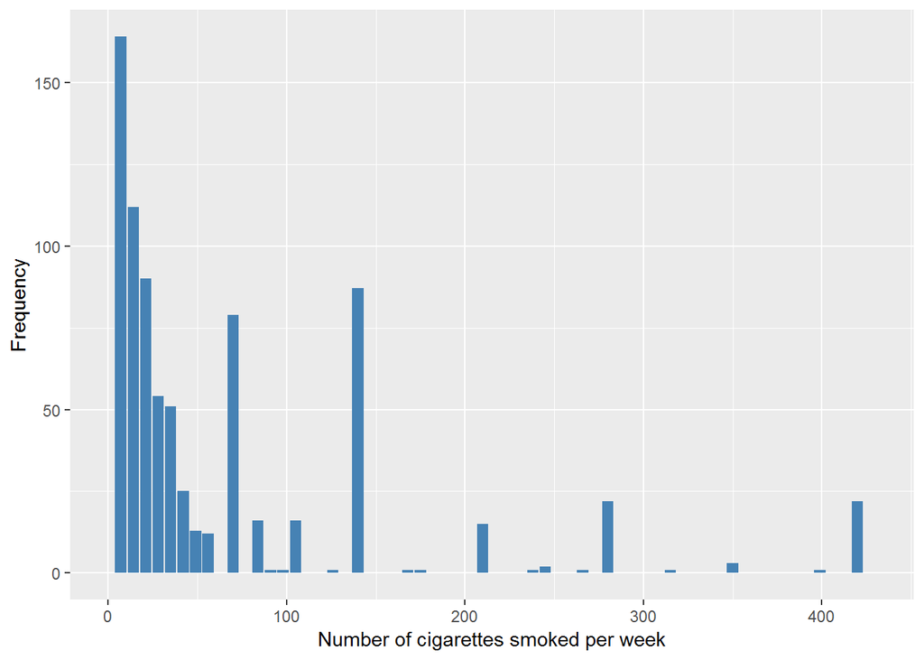

#### 2.6.1.4 Validation

|  | 1->7 | 2->14 | 3->21 | 4->28 | 5->35 | 6->42 | 7->49 | 8->56 | 10->70 | 12->84 | 13->91 | 14->98 | 15->105 | 18->126 | 20->140 | 24->168 | 25->175 | 30->210 | 34->238 | 35->245 | 38->266 | 40->280 | 45->315 | 50->350 | 57->399 | 60->420 | NA->999 |
| --- | --- | --- | --- | --- | --- | --- | --- | --- | --- | --- | --- | --- | --- | --- | --- | --- | --- | --- | --- | --- | --- | --- | --- | --- | --- | --- | --- |
| BeforeH | 164 | 112 | 90 | 54 | 51 | 25 | 13 | 12 | 79 | 16 | 1 | 1 | 16 | 1 | 87 | 1 | 1 | 15 | 1 | 2 | 1 | 22 | 1 | 3 | 1 | 22 | 1173 |
| AfterH | 164 | 112 | 90 | 54 | 51 | 25 | 13 | 12 | 79 | 16 | 1 | 1 | 16 | 1 | 87 | 1 | 1 | 15 | 1 | 2 | 1 | 22 | 1 | 3 | 1 | 22 | 1173 |

### 2.6.2 Wave 2

#### 2.6.2.1 Study-specific variable description

| **Name** | `f_PCIGDOSE` |
| --- | --- |
| **Label** | `amount smoked` |
| **Table name** | `1066-Venezuela-Followup` |
| **Categories** | `continuous` |
| **Missings** | `NA` |
| **Description** |  |

f_PCIGDOSE

| Sample size | Missing values |
| --- | --- |
| 1257 | 1158 |

Summary

| Min. | 1st Qu. | Median | Mean | 3rd Qu. | Max. | NA’s |
| --- | --- | --- | --- | --- | --- | --- |
| 1 | 3 | 6 | 9.253 | 10 | 60 | 1158 |

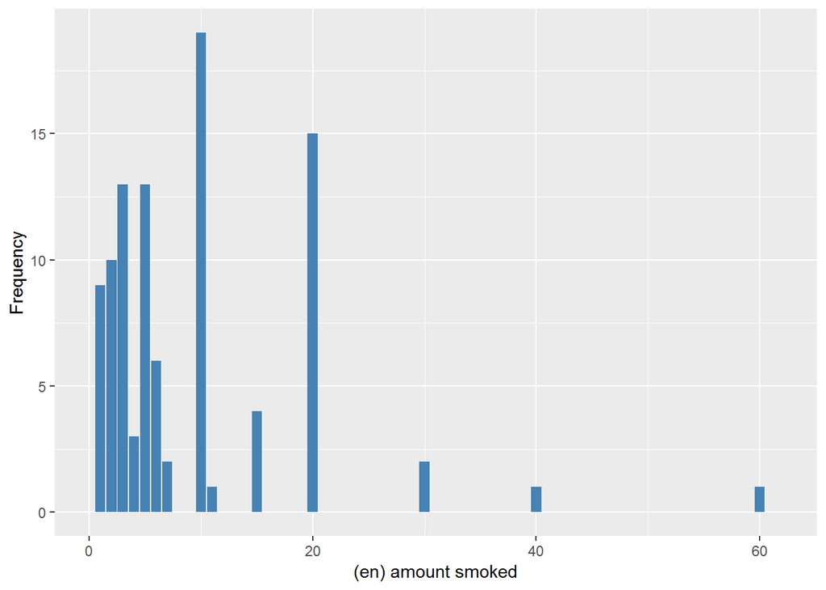

#### 2.6.2.2 Harmonisation algorithm

To compute the harmonize variable from the study-specific variable it has to be recoded as follows:

- `f_PCIGDOSE*7`
- `NA into 999`

```r
t1066_ds_Ven_w2 <- tibble(id = t1066_Ven_w2$id)
t1066_ds_Ven_w2$n_cigarettes <- Recode(t1066_Ven_w2$f_PCIGDOSE * 7, "NA = '999' ")
t1066_ds_Ven_w2$n_cigarettes <- labelled(t1066_ds_Ven_w2$n_cigarettes, labels = c(Missing = 999,
    Do_not_know = 998, Refuse = 997, Not_applicable = 996, Does_not_answer = 995,
    Not_attempt_not_done = 994, Disable_to_measure = 993, Impute = 992, CAPI_interviewer_error = 991))
```

#### 2.6.2.3 Statistical description of the new harmonised variable

Number of cigarettes smoked per week

| Sample size | Missing values |
| --- | --- |
| 1257 | 1158 |

Values

|  | No-missings | 991 | 992 | 993 | 994 | 995 | 996 | 997 | 998 | 999 | NA |
| --- | --- | --- | --- | --- | --- | --- | --- | --- | --- | --- | --- |
| Frequency | 99.00 | 0 | 0 | 0 | 0 | 0 | 0 | 0 | 0 | 1158.00 | 0 |
| Percentage | 7.88 | 0 | 0 | 0 | 0 | 0 | 0 | 0 | 0 | 92.12 | 0 |

Summary

| Min. | 1st Qu. | Median | Mean | 3rd Qu. | Max. |
| --- | --- | --- | --- | --- | --- |
| 7 | 21 | 42 | 64.77 | 70 | 420 |

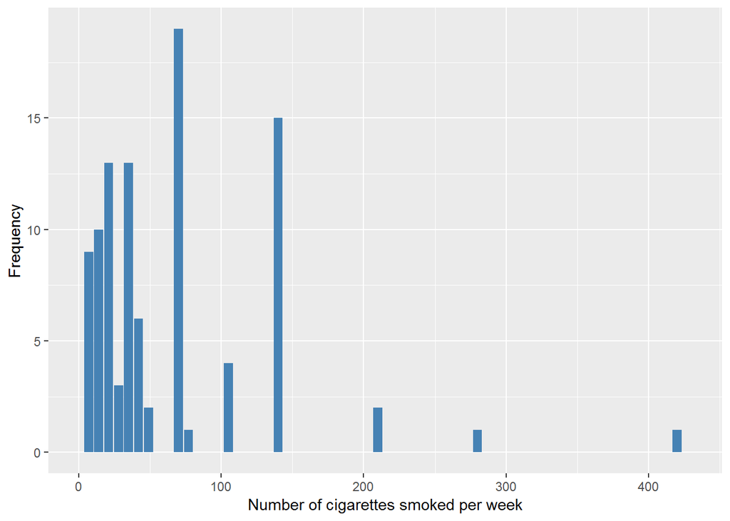

#### 2.6.2.4 Validation

|  | 1->7 | 2->14 | 3->21 | 4->28 | 5->35 | 6->42 | 7->49 | 10->70 | 11->77 | 15->105 | 20->140 | 30->210 | 40->280 | 60->420 | NA->999 |
| --- | --- | --- | --- | --- | --- | --- | --- | --- | --- | --- | --- | --- | --- | --- | --- |
| BeforeH | 9 | 10 | 13 | 3 | 13 | 6 | 2 | 19 | 1 | 4 | 15 | 2 | 1 | 1 | 1158 |
| AfterH | 9 | 10 | 13 | 3 | 13 | 6 | 2 | 19 | 1 | 4 | 15 | 2 | 1 | 1 | 1158 |

## 2.7 Urban Peru

### 2.7.1 Wave 1

#### 2.7.1.1 Study-specific variable description

| **Name** | `PCIGDOSE` |
| --- | --- |
| **Label** | `amount smoked` |
| **Table name** | `1066-UrbanPeru-Baseline` |
| **Categories** | `continuous` |
| **Missings** | `NA` |
| **Description** |  |

PCIGDOSE

| Sample size | Missing values |
| --- | --- |
| 1381 | 1170 |

Summary

| Min. | 1st Qu. | Median | Mean | 3rd Qu. | Max. | NA’s |
| --- | --- | --- | --- | --- | --- | --- |
| 1 | 2 | 5 | 10.1 | 10 | 60 | 1170 |

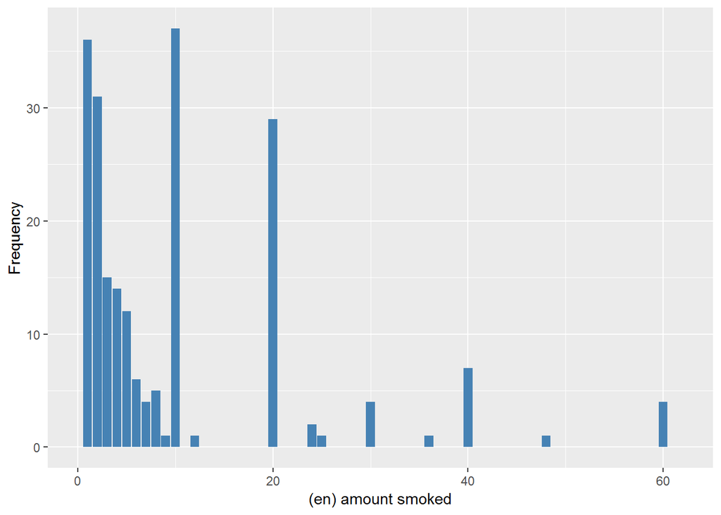

#### 2.7.1.2 Harmonisation algorithm

To compute the harmonize variable from the study-specific variable it has to be recoded as follows:

- `PCIGDOSE*7`
- `NA into 999`

```r
t1066_ds_UP_w1 <- tibble(id = t1066_UP_w1$id)
t1066_ds_UP_w1$n_cigarettes <- Recode(t1066_UP_w1$PCIGDOSE * 7, "NA = '999' ")
t1066_ds_UP_w1$n_cigarettes <- labelled(t1066_ds_UP_w1$n_cigarettes, labels = c(Missing = 999,
    Do_not_know = 998, Refuse = 997, Not_applicable = 996, Does_not_answer = 995,
    Not_attempt_not_done = 994, Disable_to_measure = 993, Impute = 992, CAPI_interviewer_error = 991))
```

#### 2.7.1.3 Statistical description of the new harmonised variable

Number of cigarettes smoked per week

| Sample size | Missing values |
| --- | --- |
| 1381 | 1170 |

Values

|  | No-missings | 991 | 992 | 993 | 994 | 995 | 996 | 997 | 998 | 999 | NA |
| --- | --- | --- | --- | --- | --- | --- | --- | --- | --- | --- | --- |
| Frequency | 211.00 | 0 | 0 | 0 | 0 | 0 | 0 | 0 | 0 | 1170.00 | 0 |
| Percentage | 15.28 | 0 | 0 | 0 | 0 | 0 | 0 | 0 | 0 | 84.72 | 0 |

Summary

| Min. | 1st Qu. | Median | Mean | 3rd Qu. | Max. |
| --- | --- | --- | --- | --- | --- |
| 7 | 14 | 35 | 70.7 | 70 | 420 |

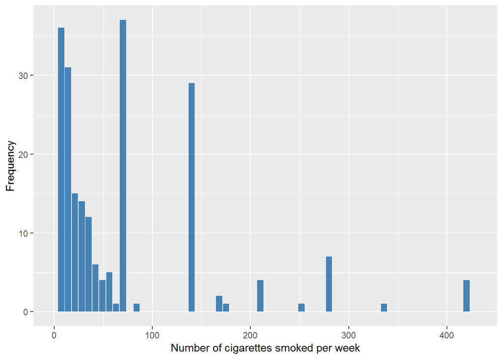

#### 2.7.1.4 Validation

|  | 1->7 | 2->14 | 3->21 | 4->28 | 5->35 | 6->42 | 7->49 | 8->56 | 9->63 | 10->70 | 12->84 | 20->140 | 24->168 | 25->175 | 30->210 | 36->252 | 40->280 | 48->336 | 60->420 | NA->999 |
| --- | --- | --- | --- | --- | --- | --- | --- | --- | --- | --- | --- | --- | --- | --- | --- | --- | --- | --- | --- | --- |
| BeforeH | 36 | 31 | 15 | 14 | 12 | 6 | 4 | 5 | 1 | 37 | 1 | 29 | 2 | 1 | 4 | 1 | 7 | 1 | 4 | 1170 |
| AfterH | 36 | 31 | 15 | 14 | 12 | 6 | 4 | 5 | 1 | 37 | 1 | 29 | 2 | 1 | 4 | 1 | 7 | 1 | 4 | 1170 |

### 2.7.2 Wave 2

#### 2.7.2.1 Study-specific variable description

| **Name** | `f_PCIGDOSE` |
| --- | --- |
| **Label** | `amount smoked` |
| **Table name** | `1066-UrbanPeru-Followup` |
| **Categories** | `continuous` |
| **Missings** | `NA` |
| **Description** |  |

f_PCIGDOSE

| Sample size | Missing values |
| --- | --- |
| 890 | 856 |

Summary

| Min. | 1st Qu. | Median | Mean | 3rd Qu. | Max. | NA’s |
| --- | --- | --- | --- | --- | --- | --- |
| 1 | 2 | 5 | 7.824 | 10 | 30 | 856 |

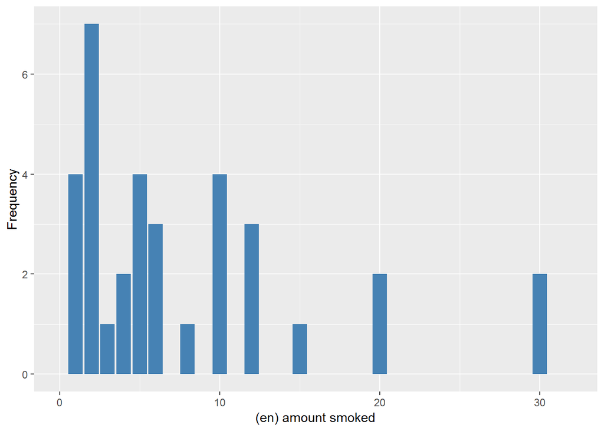

#### 2.7.2.2 Harmonisation algorithm

To compute the harmonize variable from the study-specific variable it has to be recoded as follows:

- `f_PCIGDOSE*7`
- `NA into 999`

```r
t1066_ds_UP_w2 <- tibble(id = t1066_UP_w2$id)
t1066_ds_UP_w2$n_cigarettes <- Recode(t1066_UP_w2$f_PCIGDOSE * 7, "NA = '999' ")
t1066_ds_UP_w2$n_cigarettes <- labelled(t1066_ds_UP_w2$n_cigarettes, labels = c(Missing = 999,
    Do_not_know = 998, Refuse = 997, Not_applicable = 996, Does_not_answer = 995,
    Not_attempt_not_done = 994, Disable_to_measure = 993, Impute = 992, CAPI_interviewer_error = 991))
```

#### 2.7.2.3 Statistical description of the new harmonised variable

Number of cigarettes smoked per week

| Sample size | Missing values |
| --- | --- |
| 890 | 856 |

Values

|  | No-missings | 991 | 992 | 993 | 994 | 995 | 996 | 997 | 998 | 999 | NA |
| --- | --- | --- | --- | --- | --- | --- | --- | --- | --- | --- | --- |
| Frequency | 34.00 | 0 | 0 | 0 | 0 | 0 | 0 | 0 | 0 | 856.00 | 0 |
| Percentage | 3.82 | 0 | 0 | 0 | 0 | 0 | 0 | 0 | 0 | 96.18 | 0 |

Summary

| Min. | 1st Qu. | Median | Mean | 3rd Qu. | Max. |
| --- | --- | --- | --- | --- | --- |
| 7 | 14 | 35 | 54.76 | 70 | 210 |

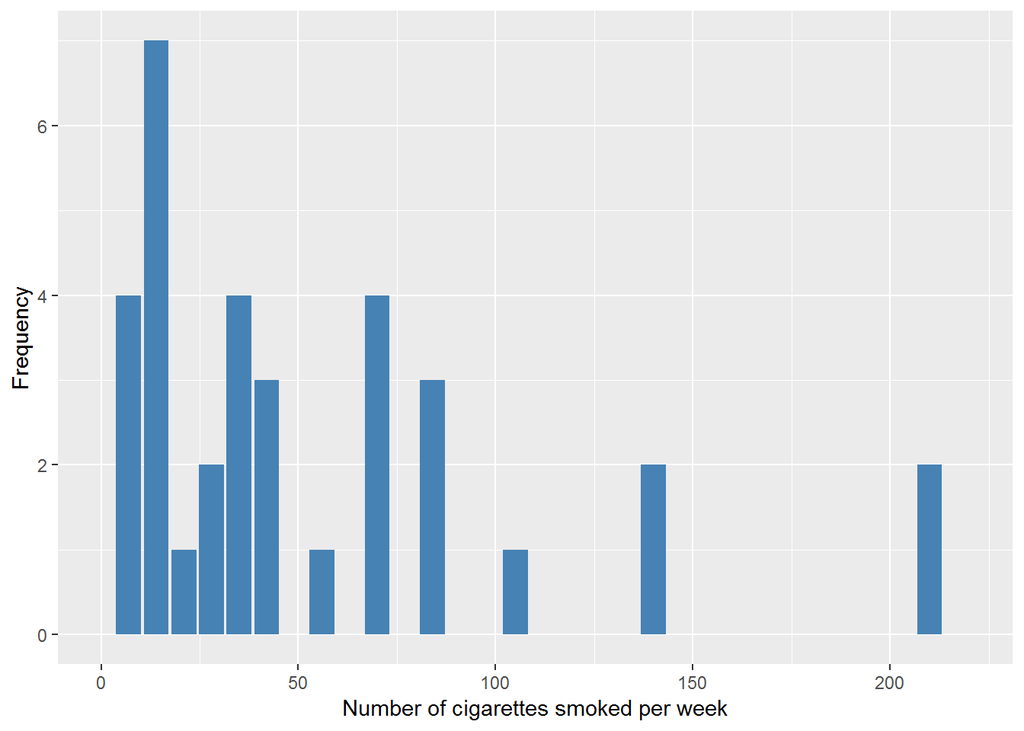

#### 2.7.2.4 Validation

|  | 1->7 | 2->14 | 3->21 | 4->28 | 5->35 | 6->42 | 8->56 | 10->70 | 12->84 | 15->105 | 20->140 | 30->210 | NA->999 |
| --- | --- | --- | --- | --- | --- | --- | --- | --- | --- | --- | --- | --- | --- |
| BeforeH | 4 | 7 | 1 | 2 | 4 | 3 | 1 | 4 | 3 | 1 | 2 | 2 | 856 |
| AfterH | 4 | 7 | 1 | 2 | 4 | 3 | 1 | 4 | 3 | 1 | 2 | 2 | 856 |

## 2.8 Rural Peru

### 2.8.1 Wave 1

#### 2.8.1.1 Study-specific variable description

| **Name** | `PCIGDOSE` |
| --- | --- |
| **Label** | `amount smoked` |
| **Table name** | `1066-RuralPeru-Baseline` |
| **Categories** | `continuous` |
| **Missings** | `NA` |
| **Description** |  |

PCIGDOSE

| Sample size | Missing values |
| --- | --- |
| 552 | 500 |

Summary

| Min. | 1st Qu. | Median | Mean | 3rd Qu. | Max. | NA’s |
| --- | --- | --- | --- | --- | --- | --- |
| 1 | 2 | 4.5 | 12.35 | 20 | 60 | 500 |

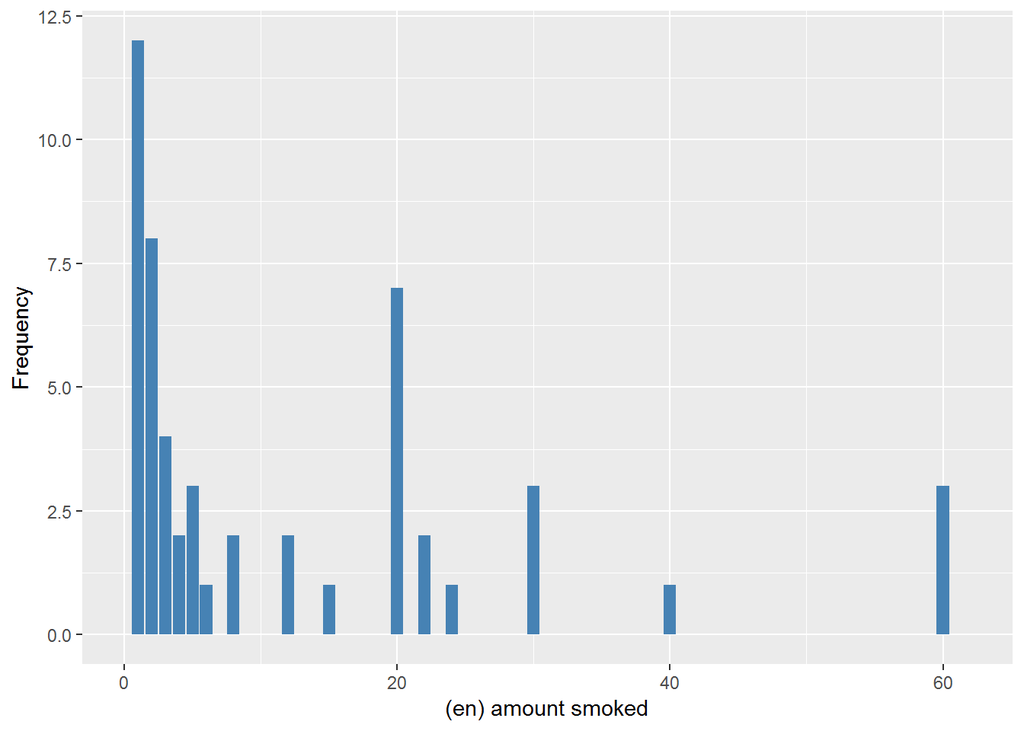

#### 2.8.1.2 Harmonisation algorithm

To compute the harmonize variable from the study-specific variable it has to be recoded as follows:

- `PCIGDOSE*7`
- `NA into 999`

```r
t1066_ds_RP_w1 <- tibble(id = t1066_RP_w1$id)
t1066_ds_RP_w1$n_cigarettes <- Recode(t1066_RP_w1$PCIGDOSE * 7, "NA = '999' ")
t1066_ds_RP_w1$n_cigarettes <- labelled(t1066_ds_RP_w1$n_cigarettes, labels = c(Missing = 999,
    Do_not_know = 998, Refuse = 997, Not_applicable = 996, Does_not_answer = 995,
    Not_attempt_not_done = 994, Disable_to_measure = 993, Impute = 992, CAPI_interviewer_error = 991))
```

#### 2.8.1.3 Statistical description of the new harmonised variable

Number of cigarettes smoked per week

| Sample size | Missing values |
| --- | --- |
| 552 | 500 |

Values

|  | No-missings | 991 | 992 | 993 | 994 | 995 | 996 | 997 | 998 | 999 | NA |
| --- | --- | --- | --- | --- | --- | --- | --- | --- | --- | --- | --- |
| Frequency | 52.00 | 0 | 0 | 0 | 0 | 0 | 0 | 0 | 0 | 500.00 | 0 |
| Percentage | 9.42 | 0 | 0 | 0 | 0 | 0 | 0 | 0 | 0 | 90.58 | 0 |

Summary

| Min. | 1st Qu. | Median | Mean | 3rd Qu. | Max. |
| --- | --- | --- | --- | --- | --- |
| 7 | 14 | 31.5 | 86.42 | 140 | 420 |

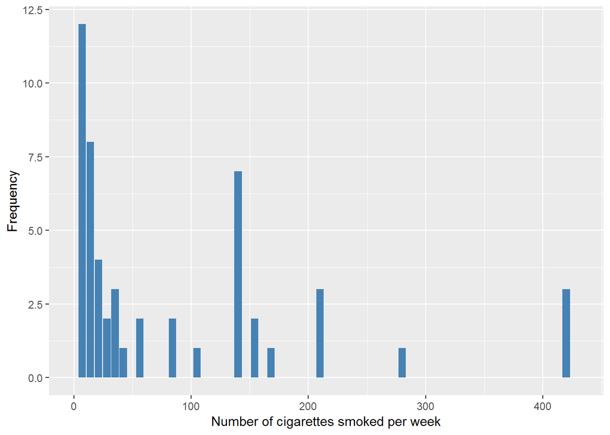

#### 2.8.1.4 Validation

|  | 1->7 | 2->14 | 3->21 | 4->28 | 5->35 | 6->42 | 8->56 | 12->84 | 15->105 | 20->140 | 22->154 | 24->168 | 30->210 | 40->280 | 60->420 | NA->999 |
| --- | --- | --- | --- | --- | --- | --- | --- | --- | --- | --- | --- | --- | --- | --- | --- | --- |
| BeforeH | 12 | 8 | 4 | 2 | 3 | 1 | 2 | 2 | 1 | 7 | 2 | 1 | 3 | 1 | 3 | 500 |
| AfterH | 12 | 8 | 4 | 2 | 3 | 1 | 2 | 2 | 1 | 7 | 2 | 1 | 3 | 1 | 3 | 500 |

### 2.8.2 Wave 2

#### 2.8.2.1 Study-specific variable description

| **Name** | `f_PCIGDOSE` |
| --- | --- |
| **Label** | `amount smoked` |
| **Table name** | `1066-RuralPeru-Followup` |
| **Categories** | `continuous` |
| **Missings** | `NA` |
| **Description** |  |

f_PCIGDOSE

| Sample size | Missing values |
| --- | --- |
| 421 | 415 |

Summary

| Min. | 1st Qu. | Median | Mean | 3rd Qu. | Max. | NA’s |
| --- | --- | --- | --- | --- | --- | --- |
| 3 | 4 | 6 | 7.833 | 8 | 20 | 415 |

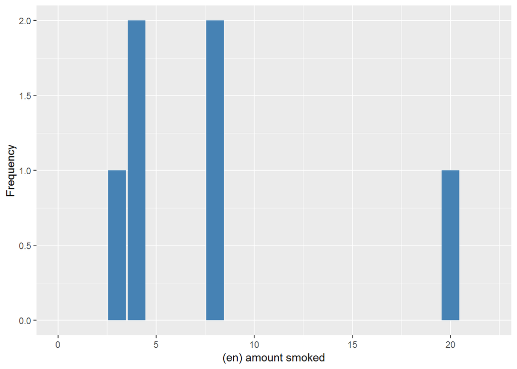

#### 2.8.2.2 Harmonisation algorithm

To compute the harmonize variable from the study-specific variable it has to be recoded as follows:

- `f_PCIGDOSE*7`
- `NA into 999`

```r
t1066_ds_RP_w2 <- tibble(id = t1066_RP_w2$id)
t1066_ds_RP_w2$n_cigarettes <- Recode(t1066_RP_w2$f_PCIGDOSE * 7, "NA = '999' ")
t1066_ds_RP_w2$n_cigarettes <- labelled(t1066_ds_RP_w2$n_cigarettes, labels = c(Missing = 999,
    Do_not_know = 998, Refuse = 997, Not_applicable = 996, Does_not_answer = 995,
    Not_attempt_not_done = 994, Disable_to_measure = 993, Impute = 992, CAPI_interviewer_error = 991))
```

#### 2.8.2.3 Statistical description of the new harmonised variable

Number of cigarettes smoked per week

| Sample size | Missing values |
| --- | --- |
| 421 | 415 |

Values

|  | No-missings | 991 | 992 | 993 | 994 | 995 | 996 | 997 | 998 | 999 | NA |
| --- | --- | --- | --- | --- | --- | --- | --- | --- | --- | --- | --- |
| Frequency | 6.00 | 0 | 0 | 0 | 0 | 0 | 0 | 0 | 0 | 415.00 | 0 |
| Percentage | 1.43 | 0 | 0 | 0 | 0 | 0 | 0 | 0 | 0 | 98.57 | 0 |

Summary

| Min. | 1st Qu. | Median | Mean | 3rd Qu. | Max. |
| --- | --- | --- | --- | --- | --- |
| 21 | 28 | 42 | 54.83 | 56 | 140 |

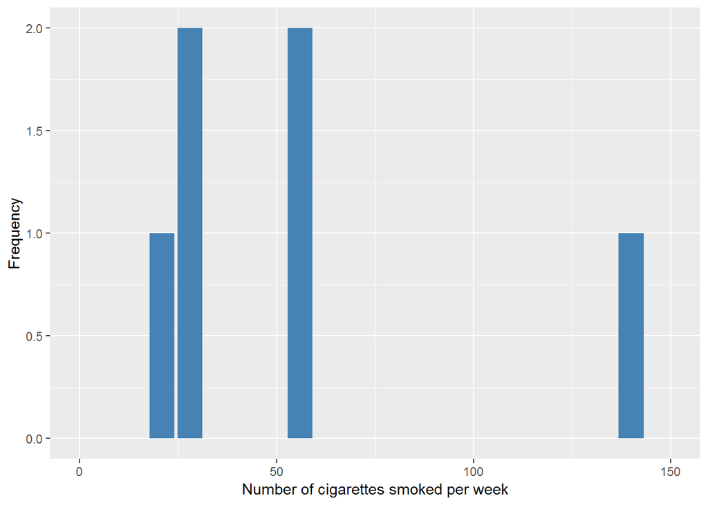

#### 2.8.2.4 Validation

|  | 3->21 | 4->28 | 8->56 | 20->140 | NA->999 |
| --- | --- | --- | --- | --- | --- |
| BeforeH | 1 | 2 | 2 | 1 | 415 |
| AfterH | 1 | 2 | 2 | 1 | 415 |

## 2.9 Urban Mexico

### 2.9.1 Wave 1

#### 2.9.1.1 Study-specific variable description

| **Name** | `PCIGDOSE` |
| --- | --- |
| **Label** | `amount smoked` |
| **Table name** | `1066-UrbanMexico-Baseline` |
| **Categories** | `continuous` |
| **Missings** | `NA` |
| **Description** |  |

PCIGDOSE

| Sample size | Missing values |
| --- | --- |
| 1003 | 667 |

Summary

| Min. | 1st Qu. | Median | Mean | 3rd Qu. | Max. | NA’s |
| --- | --- | --- | --- | --- | --- | --- |
| 1 | 2 | 4 | 8.86 | 12 | 60 | 667 |

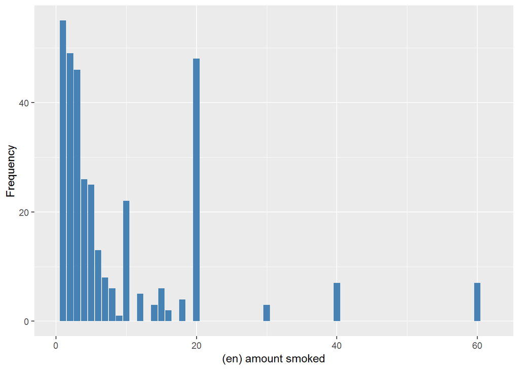

#### 2.9.1.2 Harmonisation algorithm

To compute the harmonize variable from the study-specific variable it has to be recoded as follows:

- `PCIGDOSE*7`
- `NA into 999`

```r
t1066_ds_UM_w1 <- tibble(id = t1066_UM_w1$id)
t1066_ds_UM_w1$n_cigarettes <- Recode(t1066_UM_w1$PCIGDOSE * 7, "NA = '999' ")
t1066_ds_UM_w1$n_cigarettes <- labelled(t1066_ds_UM_w1$n_cigarettes, labels = c(Missing = 999,
    Do_not_know = 998, Refuse = 997, Not_applicable = 996, Does_not_answer = 995,
    Not_attempt_not_done = 994, Disable_to_measure = 993, Impute = 992, CAPI_interviewer_error = 991))
```

#### 2.9.1.3 Statistical description of the new harmonised variable

Number of cigarettes smoked per week

| Sample size | Missing values |
| --- | --- |
| 1003 | 667 |

Values

|  | No-missings | 991 | 992 | 993 | 994 | 995 | 996 | 997 | 998 | 999 | NA |
| --- | --- | --- | --- | --- | --- | --- | --- | --- | --- | --- | --- |
| Frequency | 336.0 | 0 | 0 | 0 | 0 | 0 | 0 | 0 | 0 | 667.0 | 0 |
| Percentage | 33.5 | 0 | 0 | 0 | 0 | 0 | 0 | 0 | 0 | 66.5 | 0 |

Summary

| Min. | 1st Qu. | Median | Mean | 3rd Qu. | Max. |
| --- | --- | --- | --- | --- | --- |
| 7 | 14 | 28 | 62.02 | 84 | 420 |

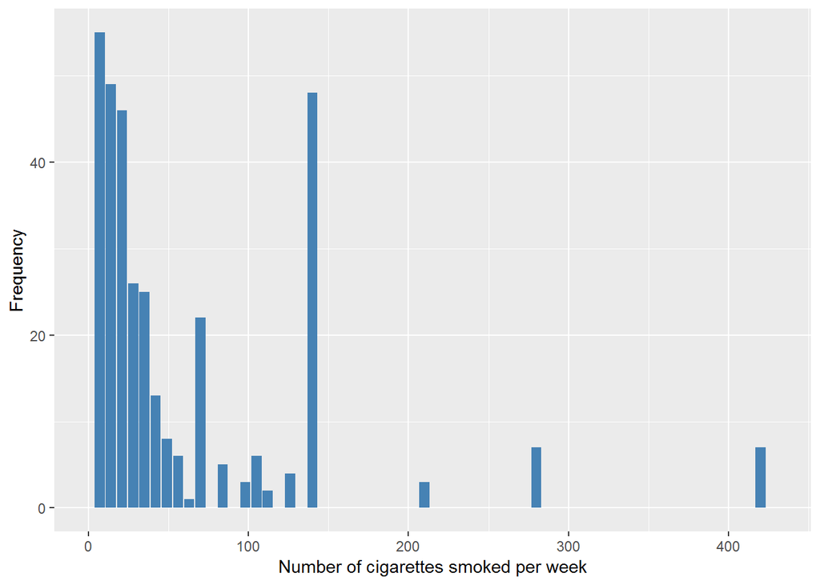

#### 2.9.1.4 Validation

|  | 1->7 | 2->14 | 3->21 | 4->28 | 5->35 | 6->42 | 7->49 | 8->56 | 9->63 | 10->70 | 12->84 | 14->98 | 15->105 | 16->112 | 18->126 | 20->140 | 30->210 | 40->280 | 60->420 | NA->999 |
| --- | --- | --- | --- | --- | --- | --- | --- | --- | --- | --- | --- | --- | --- | --- | --- | --- | --- | --- | --- | --- |
| BeforeH | 55 | 49 | 46 | 26 | 25 | 13 | 8 | 6 | 1 | 22 | 5 | 3 | 6 | 2 | 4 | 48 | 3 | 7 | 7 | 667 |
| AfterH | 55 | 49 | 46 | 26 | 25 | 13 | 8 | 6 | 1 | 22 | 5 | 3 | 6 | 2 | 4 | 48 | 3 | 7 | 7 | 667 |